# Course_8_Project

Michael Shealy

6/8/2021

# Course 8 Project

### Michael Shealy

First let’s import the data

```r
training <- read.csv("pml-training.csv")
testing <- read.csv("pml-testing.csv")
dim(training)
```

```
## [1] 19622   160
```

```r
library(caret)
```

```r
library(ggplot2)
library(randomForest)
set.seed(3433)
```

Now let’s do some exploratory data analysis on the training data:

```r
table(sapply(training,class))
```

```
##
## character   integer   numeric
##        37        35        88
```

We have 37 character columns, 35 integer columns, and 88 numeric columns. Let’s first look at the proportion of missing values for each of the features:

```r
na_props <- data.frame(sapply(training,function(y) length(which(is.na(y)|y==""))/length(y)))
colnames(na_props) <- c("prop")
data.frame(na_props[order(-na_props$prop),])
```

```
##     na_props.order..na_props.prop....
## 1                           0.9793089
## 2                           0.9793089
## 3                           0.9793089
## 4                           0.9793089
## 5                           0.9793089
## 6                           0.9793089
## 7                           0.9793089
## 8                           0.9793089
## 9                           0.9793089
## 10                          0.9793089
## 11                          0.9793089
## 12                          0.9793089
## 13                          0.9793089
## 14                          0.9793089
```

[output cut: 146 more lines]

100 of the 160 columns have exactly 97.93089% of missing values or blank characters representing missing values. This suggests that there are certain rows in the dataset with missing values in all these columns. We will drop these columns as they would be difficult to accurately impute:

```r
training <- training[,-which(na_props$prop>0)]
```

The rowid, username,timestamp, and window columns are not relevant to the predictions we want to make and we do not want them interfering with the prediction. We will drop these columns:

```r
training <- training[,-c(1:7)]
```

We now have only numeric data as the features of this dataset, with no missing values. Let’s see if any of the features have minimal variance:

```r
nsv <- nearZeroVar(training,saveMetrics = TRUE)
nsv
```

```
##                      freqRatio percentUnique zeroVar   nzv
## roll_belt             1.101904     6.7781062   FALSE FALSE
## pitch_belt            1.036082     9.3772296   FALSE FALSE
## yaw_belt              1.058480     9.9734991   FALSE FALSE
## total_accel_belt      1.063160     0.1477933   FALSE FALSE
## gyros_belt_x          1.058651     0.7134849   FALSE FALSE
## gyros_belt_y          1.144000     0.3516461   FALSE FALSE
## gyros_belt_z          1.066214     0.8612782   FALSE FALSE
## accel_belt_x          1.055412     0.8357966   FALSE FALSE
## accel_belt_y          1.113725     0.7287738   FALSE FALSE
## accel_belt_z          1.078767     1.5237998   FALSE FALSE
## magnet_belt_x         1.090141     1.6664968   FALSE FALSE
## magnet_belt_y         1.099688     1.5187035   FALSE FALSE
## magnet_belt_z         1.006369     2.3290184   FALSE FALSE
## roll_arm             52.338462    13.5256345   FALSE FALSE
## pitch_arm            87.256410    15.7323412   FALSE FALSE
## yaw_arm              33.029126    14.6570176   FALSE FALSE
## total_accel_arm       1.024526     0.3363572   FALSE FALSE
## gyros_arm_x           1.015504     3.2769341   FALSE FALSE
## gyros_arm_y           1.454369     1.9162165   FALSE FALSE
## gyros_arm_z           1.110687     1.2638875   FALSE FALSE
## accel_arm_x           1.017341     3.9598410   FALSE FALSE
## accel_arm_y           1.140187     2.7367241   FALSE FALSE
## accel_arm_z           1.128000     4.0362858   FALSE FALSE
## magnet_arm_x          1.000000     6.8239731   FALSE FALSE
## magnet_arm_y          1.056818     4.4439914   FALSE FALSE
## magnet_arm_z          1.036364     6.4468454   FALSE FALSE
## roll_dumbbell         1.022388    84.2065029   FALSE FALSE
## pitch_dumbbell        2.277372    81.7449801   FALSE FALSE
## yaw_dumbbell          1.132231    83.4828254   FALSE FALSE
## total_accel_dumbbell  1.072634     0.2191418   FALSE FALSE
## gyros_dumbbell_x      1.003268     1.2282132   FALSE FALSE
## gyros_dumbbell_y      1.264957     1.4167771   FALSE FALSE
## gyros_dumbbell_z      1.060100     1.0498420   FALSE FALSE
## accel_dumbbell_x      1.018018     2.1659362   FALSE FALSE
## accel_dumbbell_y      1.053061     2.3748853   FALSE FALSE
## accel_dumbbell_z      1.133333     2.0894914   FALSE FALSE
## magnet_dumbbell_x     1.098266     5.7486495   FALSE FALSE
## magnet_dumbbell_y     1.197740     4.3012945   FALSE FALSE
## magnet_dumbbell_z     1.020833     3.4451126   FALSE FALSE
## roll_forearm         11.589286    11.0895933   FALSE FALSE
## pitch_forearm        65.983051    14.8557741   FALSE FALSE
## yaw_forearm          15.322835    10.1467740   FALSE FALSE
## total_accel_forearm   1.128928     0.3567424   FALSE FALSE
## gyros_forearm_x       1.059273     1.5187035   FALSE FALSE
## gyros_forearm_y       1.036554     3.7763735   FALSE FALSE
## gyros_forearm_z       1.122917     1.5645704   FALSE FALSE
## accel_forearm_x       1.126437     4.0464784   FALSE FALSE
## accel_forearm_y       1.059406     5.1116094   FALSE FALSE
## accel_forearm_z       1.006250     2.9558659   FALSE FALSE
## magnet_forearm_x      1.012346     7.7667924   FALSE FALSE
## magnet_forearm_y      1.246914     9.5403119   FALSE FALSE
## magnet_forearm_z      1.000000     8.5771073   FALSE FALSE
## classe                1.469581     0.0254816   FALSE FALSE
```

None of the features seem to be monotonous in their information, which is a good sign. Next, we are going to perform PCA on the training set to see if we can maximize the retained variance into a few principal components. We will standardize the data prior to performing the procedure. If the amount of principal components required to retain a good amount of variance is still large, we will not use the results in the modeling:

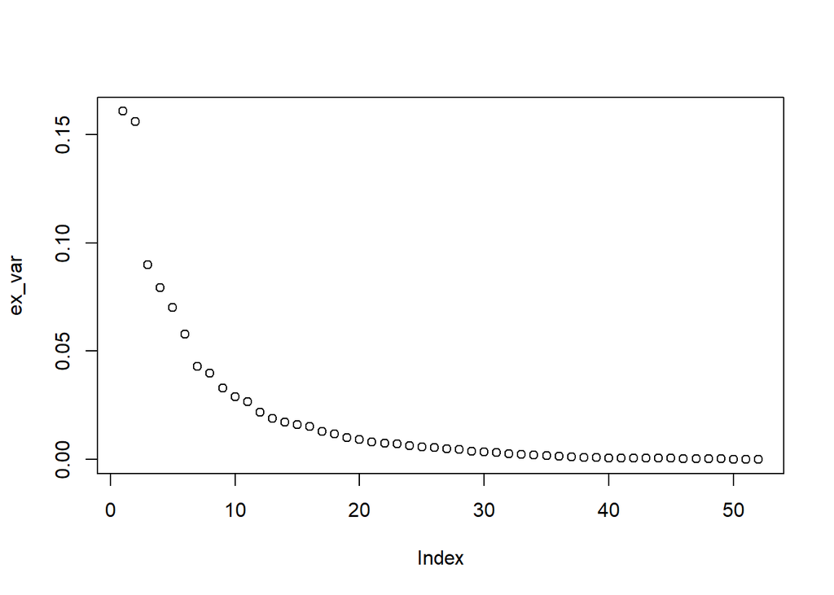

```r
classe <- training$classe
training <- training[,-53]

pca <- prcomp(training, scale=TRUE)
eigs <- pca$sdev^2
ex_var <- eigs / sum(eigs)
plot(ex_var)
```

```r
total = 0
i=1
while (total < 0.9) {
  total <- total + ex_var[i]
  i <- i + 1
}
i
```

```
## [1] 20
```

Using PCA, we were able to explain 90% of the variance in the data within 20 principal components. We will use these components for model training.

We will use a random forest model to predict the classe of the data. This is a computationally intensive model to train, so we will use the “parallel” package to speed up the process:

```r
pca_training <- pca$x[,1:20]
pca_training <- data.frame(pca_training)
pca_training <- cbind(pca_training,classe)
pca_training$classe <- as.factor(pca_training$classe)

library(parallel)
library(doParallel)
cluster <- makeCluster(detectCores()-1)
registerDoParallel(cluster)

fitControl <- trainControl(method="cv", number=5, allowParallel = TRUE)
```

```r
rf_model <- randomForest(classe~.,data=pca_training,trControl=fitControl)
```

```r
stopCluster(cluster)
registerDoSEQ()
```

```r
rf_model
```

```
##
## Call:
##  randomForest(formula = classe ~ ., data = pca_training, trControl = fitControl)
##                Type of random forest: classification
##                      Number of trees: 500
## No. of variables tried at each split: 4
##
##         OOB estimate of  error rate: 1.72%
## Confusion matrix:
##      A    B    C    D    E class.error
## A 5548   12   15    3    2 0.005734767
## B   44 3712   34    1    6 0.022386094
## C    3   35 3352   29    3 0.020455874
## D    4    1  100 3107    4 0.033893035
## E    0    7   19   16 3565 0.011644026
```

The Random Forest function automatically calculates the OOB error rate, which in this case is 1.72%. For predicting between 5 different classes, this is an excellent error rate.

Let’s perform the required preprocessing steps on the test dataset and see what the model predicts for these observations:

```r
na_props <- data.frame(sapply(testing,function(y) length(which(is.na(y)|y==""))/length(y)))
colnames(na_props) <- c("prop")
testing <- testing[,-which(na_props$prop>0)]
testing <- testing[,-c(1:7)]
problem_id <- testing$problem_id
testing <- testing[,-53]
pca_testing <- predict(pca,testing)[,1:20]
```

```r
predict(rf_model,pca_testing)
```

```
##  1  2  3  4  5  6  7  8  9 10 11 12 13 14 15 16 17 18 19 20
##  B  A  A  A  A  E  D  B  A  A  B  C  B  A  E  E  A  B  B  B
## Levels: A B C D E
```

Overall, the random forest approach to predicting the classe was successful when combined with the appropriate preprocessing steps.